# **The accelerated R Course:** Practical 3 *Data, functions, and tidying*

Chris Clements

# 1 Pre-session reading

**Time - 20 minutes**

## 1.1 Recap

So, in the first workshop we introduced you to R and RStudio, and taught you the basics ways in which you can use R. To quickly refresh, we covered:

- Working in the console vs writing a script
- Annotating your code
- Assigning objects
- `Inf`, `NaN`, `NA`
- Naming conventions
- Vectors (numeric, character, logical)
- Accessing data using `[]`
- Logical operators (`==`, `!=`, `>`, etc)
- Functions
- Writing your own functions
- Getting help

And in the second workshop we covered Github and RMarkdown.

Today, we are going start using R “properly” - starting to work with more complex data structures and learning how we can manipulate and work with these data structures to get out the information we want. Throughout this workbook we will be introducing a lot of new functions, some we will go into depth explaining, others we won’t. If you need to get more details on a function then remember to use `?` or google to find your answers.

## 1.2 ILOs

This week our ILOs are:

- Learn about the different data structures in R
  - Vectors, matrices, arrays, data.frames, lists
- Learn how to install packages from CRAN
- Learn how to install packages from Github
- Learn how to load data into R
- Learn the basic concepts of the Tidyverse
- Learn how to create pipelines via the `magrittr` operator `%>%`
- Learn how to reshape data

## 1.3 Tasks and code

Throughout these workbooks you will come across tasks you need to carry out. For some of the more complex ones the answers will be provided so you can check whether what you have done is correct. I shouldn’t need to state the obvious, but you should be attempting these tasks by yourself before you look at the code answer! That is there just to help you if you can’t get your code working, and should be a last resort. To show the code simply click on the `Code` button:

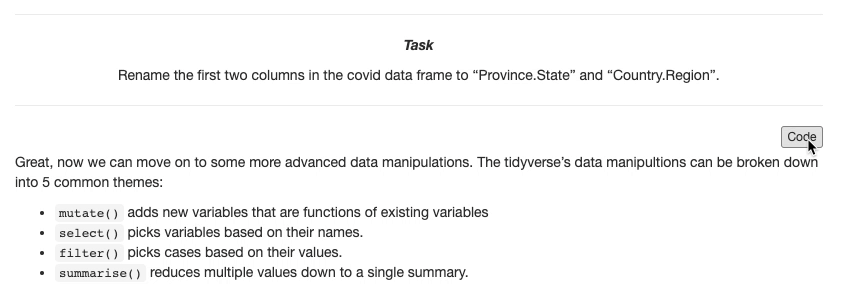

## 1.4 Recapping vectors - numeric, character, logical

Vectors can be numeric, character, or logical but cannot be a mix of these different data types.

We can construct vectors using the `c()` command, or vectors are often the output of functions we are using (such as `runif()` which generates random numbers from a uniform distribution).

We can access the data in vectors using square bracks `[]`, either specifying the position in the vector of the data we want (i.e. `myvec[4]`) or, if we have named the objects in the vector, then we can use the names (i.e. `myvec["a"]`, or, if we want to extract multiple named values `myvec[c("a", "n")]`).

Logical operators and logical vectors are really useful ways of subsetting data (e.g. `random_nums[random_nums > 48]`).

*Task*

Combine these two vectors into a single vector:

`c(1, 4, 2, 1, 7)` & `c(3, 2)`

```r
c(c(1, 4, 2, 1, 7), c(3, 2))
```

## 1.5 Refreshing matrix multiplication (optional)

Matrix multiplication is a specific operation which produces a single matrix from two matrices. It differs from the “normal” way R does multiplication (more on that later) and indeed matrix multiplication isn’t something we are going to use on this course. However, it is important to note that R does not carry out matrix multiplication as its default, and it might be worth quickly familiarising yourself with what matrix multiplication is (so you know what you are not doing). For a good brief explanation, see [here](https://www.youtube.com/watch?v=OMA2Mwo0aZg&ab_channel=KhanAcademy).

# 2 Data structures in R

**Time - 80 minutes**

In the first workshop we introduced the concept of vectors - numeric, character, and logical. Lets briefly recap what we learnt, and then move onto the other data structures R can handle. Vectors however will continue to be critical for our use of R - they are the data that is fed into many functions, and which is returned by many functions, and logical vectors will become increasingly important when we are dealing with more complex data structures.

## 2.1 Matrices

Vectors are one dimensional matrices:

```
## [1] 1 2 3 4 5 6 7 8 9
```

Matrices have two dimensions:

```
##      [,1] [,2] [,3]
## [1,]    1    4    7
## [2,]    2    5    8
## [3,]    3    6    9
```

Arrays (see below) are n-dimensional matrices.

Because matrices are 2-dimensional vectors, the same rules apply - matrices can be either numeric **or** character, but not both. Matrices form the backbone of a lot of statistics (consider the variance-covariance matrix in a regression), and R creates them using the `matrix()` function:

```r
##where the first argument is the data to be included in the matrix.
##Here we are using the seq() function which generates regular sequences (see ?seq() for more information)
##and the second and third arguments specify the shape of the matrix (number of columns, and number of rows).
matrix(seq(from = 1, to = 6, by = 1), ncol = 3, nrow = 2)
```

```
##      [,1] [,2] [,3]
## [1,]    1    3    5
## [2,]    2    4    6
```

```r
##creating a blank matrix full of NAs
matrix(NA, ncol = 3, nrow = 4)
```

```
##      [,1] [,2] [,3]
## [1,]   NA   NA   NA
## [2,]   NA   NA   NA
## [3,]   NA   NA   NA
## [4,]   NA   NA   NA
```

```r
##you can also shape a vector into a matrix using the dim() function:
b <- seq(from = 1, to = 6, by = 1)

##set the dimensions of the matrix (nrows and then ncolumns)
dim(b) <- c(2, 3)

##look at the matrix
b
```

```
##      [,1] [,2] [,3]
## [1,]    1    3    5
## [2,]    2    4    6
```

`dim()` can also be used to show us the properties of a matrix - i.e. its dimensions. (*Remember that `names()` could be used to both ascribe names to a vector, and see the names that a vector had been given*).

Here we have used a quick trick to fill the matrix - the `:` between two numbers means "generate a sequence of whole numbers from x to y. Try running `1:6` in your console to see.

```r
##the dimensions of the matrix - returned as the number of rows in the matrix first, and the number of columns second.
##here we make a matrix and look at the dimensions
dim(matrix(1:6, ncol = 3, nrow = 2))
```

```
## [1] 2 3
```

*Task*

Make a matrix of 80 random numbers drawn from a normal distribution (see the function `rnorm()`). You can decide on the values for mean and sd, and the dimensions of the matrix.

As with vectors, the values stored in matrices can be accessed using the `[ ]` operator. When we were dealing with vectors we could specify an object using its position in the vector. As a vector is only 1 dimensional we only had to supply a single value:

```r
seq(from = 1, to = 10, by = 1)[5]
```

```
## [1] 5
```

But, as we know, matrices are 2 dimensional. This can change how we interact with them. So now, instead of specifying a single value for the position in the vector we should give two values - the first determines the row that R should look in, the second determining the column - therefore:

```r
##make a matrix and look at it
our_matrix <- matrix(6:1, ncol = 3, nrow = 2)
our_matrix
```

```
##      [,1] [,2] [,3]
## [1,]    6    4    2
## [2,]    5    3    1
```

```r
##return the value of the matrix in the first row and the second column
our_matrix[1, 2]
```

```
## [1] 4
```

**Remember** - for square brackets the order is always `[row, column]` when you are accessing a 2-dimensional object.

You can also return multiple values by giving either the row or column values as a vector:

```r
##return the values in the first row from the first and second column:
our_matrix[1,c(1,2)]
```

```
## [1] 6 4
```

Or whole rows or columns:

```r
##return the values in the first row
our_matrix[1,]
```

```
## [1] 6 4 2
```

```r
##return the values in the second column
our_matrix[,2]
```

```
## [1] 4 3
```

### 2.1.1 Matrix operations

Matrices can be added, subtracted, multiplied, and divided by one another, whether that is a two dimensional matrix or a one dimensional vector. These are specificed through the normal operators (`+`, `-`, etc). When the vector you are using is of length 1 - then R simply recycles this for every value in the matrix:

```r
## a matrix of values:
init_mat <- matrix(1:6, ncol=3, nrow=2)

##add 1 to all of the values
init_mat+1
```

```
##      [,1] [,2] [,3]
## [1,]    2    4    6
## [2,]    3    5    7
```

When the vector is of length > 1 then something different happens.

*Important* - As with vectors R approaches matrix multiplication depending on how you specify the multiplication - if you use the `*` symbol, R will perform element-wise multiplication, whilst if you need true matrix multiplication ([see here for a refresher](https://en.wikipedia.org/wiki/Matrix_multiplication)) you need a special operator `%*%` (see below).

```r
##Make a matrix. Here we are using rep() to replicate the numbers 1, 2, and 3 five times.
##Trying running: rep(1:3, each = 5)
##We are then filling our matrix "byrow =TRUE" - which you can see makes a matrix
mat_rep <- matrix(rep(1:3, each = 5), nrow = 3, ncol = 5, byrow = TRUE)
mat_rep
```

```
##      [,1] [,2] [,3] [,4] [,5]
## [1,]    1    1    1    1    1
## [2,]    2    2    2    2    2
## [3,]    3    3    3    3    3
```

```r
## a vector of the numbers 1 to 5
vec_seq <- 1:5

##multiple the matrices using element-wise multiplication
mat_rep * vec_seq
```

```
##      [,1] [,2] [,3] [,4] [,5]
## [1,]    1    4    2    5    3
## [2,]    4   10    6    2    8
## [3,]    9    3   12    6   15
```

From this you can see that R has done the following:

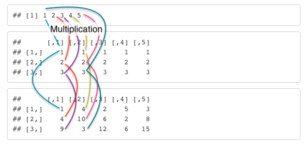

It has multipled the 1st number in the vector with the 1st number in column one, the 2nd number in the vector by the 2nd number in column 1, etc…, and has then rolled over from bottom of column 1 to the top of column 2 and so on. There is nothing wrong with this, we just have to bear this in mind when coding.

### 2.1.2 Matrix multiplication

If we want to perform true matrix multiplication, we can:

```r
##where the first argument is the data to be included in the matrix, and the second and third arguments specify the shape of the matrix.
mat_seq <- matrix(seq(from = 1, to = 20, length.out = 6), ncol = 3, nrow = 2)

##a vector to multiply by
vec_seq <- seq(from = 10, to = 4, length.out = 3)

##multiple the matrices using element-wise multiplication
mat_seq %*% vec_seq
```

```
##       [,1]
## [1,] 135.0
## [2,] 214.8
```

### 2.1.3 Data in matrices

```r
##make a matrix
mat_seq <- matrix(seq(1, 20, length.out = 6), ncol=3, nrow=2)

## display the logical operator of this matrix for values greater than 10
mat_seq > 10
```

```
##       [,1]  [,2] [,3]
## [1,] FALSE FALSE TRUE
## [2,] FALSE  TRUE TRUE
```

```r
##return the values which are greater than 10
mat_seq[mat_seq > 10]
```

```
## [1] 12.4 16.2 20.0
```

Because matrices are used so widely in statistics, there are a whole raft of tools available to perform matrix algebra on matrices. The great thing about these functions is that they are very efficient, and so very quick even when dealing with large matrices. Here are some select examples, and for a longer list see [here](https://www.statmethods.net/advstats/matrix.html).

| Description | Code | Example |
| --- | --- | --- |
| Transpose | `t()` | `t(matrix(1:2, ncol = 1, nrow = 2))` |
| Create matrix where diagonal is filled with x | `diag()` | `x<-1:5; diag(x)` |
| Return the diagonal of a matrix | `diag()` | `diag(matrix(1:9, ncol = 3, nrow = 3))` |
| Calculate eighenvalues and eigenvectors | `eigen()` | `eigen(matrix(1:9, ncol = 3, nrow = 3))` |
| Sums of the rows | `rowSums()` | `rowSums(matrix(1:9, ncol = 3, nrow = 3))` |
| Sums of the columns | `cowSums()` | `rowSums(matrix(1:9, ncol = 3, nrow = 3))` |
| Means of the rows | `rowMeans()` | `rowMeans(matrix(1:9, ncol = 3, nrow = 3))` |
| Means of the columns | `colMeans()` | `rowMeans(matrix(1:9, ncol = 3, nrow = 3))` |

We will also spend some time later on looking at some more advanced matrix functions which can do more complex calculations.

## 2.2 Arrays

Now we are getting into the more complex data structures R can deal with. Arrays are a relatively easy extension to matrices - at least when they have 3 dimensions - the easiest way to imagine it is that you have a matrix, and then another one behind it, and potentially another behind that etc.

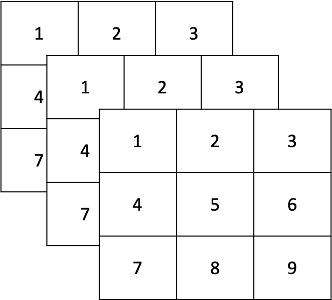

However, as with so many things this easy visualisation isn’t actually exactly whats going on. In actuality the data is sorted in an n dimensional data object, which allows you to access any rows or column combinations from any dimension.

But lets start with a simple array:

```r
this_is_an_array <- array(1:24, dim=c(3,4,2))
this_is_an_array
```

```
## , , 1
##
##      [,1] [,2] [,3] [,4]
## [1,]    1    4    7   10
## [2,]    2    5    8   11
## [3,]    3    6    9   12
##
## , , 2
##
##      [,1] [,2] [,3] [,4]
## [1,]   13   16   19   22
## [2,]   14   17   20   23
## [3,]   15   18   21   24
```

So you can see that specifying the dimensions using `dim = c()` shapes an array in the same way it shapes a matrix. We specified there were going to be three rows, four columns, and two matrix levels to the array by writing `dim = c(3, 4, 2)`. So looking back at the earlier figure of the arrays, here we have two matrices, one behind the other. R displays this as two matrices, with the levels in the 3rd dimension displayed above each:

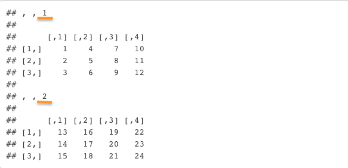

Alternatively we could do:

```r
array(1:24, dim=c(3,2,4))
```

```
## , , 1
##
##      [,1] [,2]
## [1,]    1    4
## [2,]    2    5
## [3,]    3    6
##
## , , 2
##
##      [,1] [,2]
## [1,]    7   10
## [2,]    8   11
## [3,]    9   12
##
## , , 3
##
##      [,1] [,2]
## [1,]   13   16
## [2,]   14   17
## [3,]   15   18
##
## , , 4
##
##      [,1] [,2]
## [1,]   19   22
## [2,]   20   23
## [3,]   21   24
```

And have four smaller matrices of three rows and two columns.

But because arrays are n dimensional, we can also do:

```r
still_an_array <- array(1:24, dim = c(3,2,2,4))
dim(still_an_array)
```

```
## [1] 3 2 2 4
```

```r
still_an_array
```

```
## , , 1, 1
##
##      [,1] [,2]
## [1,]    1    4
## [2,]    2    5
## [3,]    3    6
##
## , , 2, 1
##
##      [,1] [,2]
## [1,]    7   10
## [2,]    8   11
## [3,]    9   12
##
## , , 1, 2
##
##      [,1] [,2]
## [1,]   13   16
## [2,]   14   17
## [3,]   15   18
##
## , , 2, 2
##
##      [,1] [,2]
## [1,]   19   22
## [2,]   20   23
## [3,]   21   24
##
## , , 1, 3
##
##      [,1] [,2]
## [1,]    1    4
## [2,]    2    5
## [3,]    3    6
##
## , , 2, 3
##
##      [,1] [,2]
## [1,]    7   10
## [2,]    8   11
## [3,]    9   12
##
## , , 1, 4
##
##      [,1] [,2]
## [1,]   13   16
## [2,]   14   17
## [3,]   15   18
##
## , , 2, 4
##
##      [,1] [,2]
## [1,]   19   22
## [2,]   20   23
## [3,]   21   24
```

Arrays are high dimensional, but functions like `length()` and `names()` will still work with these data structures as they have high-dimensional generalisations.

*Task*

Create an array containing 100 random numbers drawn from a uniform distribution (see `runif()`) with at least 3 groups. Consider the limitations in terms of the dimensions you can specify given the length of the data you are adding to the matrix.

## 2.3 Data frames

We know matrices follow the same rules as vectors - they can only store one sort of data (numeric, character, or logical) but we often want to mix data types. This is where data frames come in - they allow us to store multiple different types of data in the same data structure and work with it. Data frames are the most common data structure in R.

We can create data frames using the `data.frame()` function as follows:

```r
##make a data frame with information on whether a Species was seen (1 = yes, 0 = no), on a particular Day:
our_data <- data.frame("Day" = rep(1:3, each = 3),
                       "Species" = rep(letters[1:3], each = 3),
                       "Seen" = rbinom(n = 9, size = 1, prob = 0.5))

##look at the Day column
our_data["Day"]
```

```
##   Day
## 1   1
## 2   1
## 3   1
## 4   2
## 5   2
## 6   2
## 7   3
## 8   3
## 9   3
```

*Note* - look into the `rbinom()` function and what it does.

So you can see here above that we have a data object where we mix numeric and character values. The best way to think of this is that a data.frame is in effect a series of vectors arranged in columns - within a column the data types can’t mix, but across columns they can.

There are some other things to notice about this code - we specify the names for each of the columns in the data.frame using the form `"Name" =`.

We can still access data in the data frame using the `our_data[1,2]` and `our_data["Day"]` approach earlier, however with this new structure we can also access the data via the `$` operator:

```r
##access the Day column
our_data$Day
```

```
## [1] 1 1 1 2 2 2 3 3 3
```

Which returns the vector found in the column “Day”.

We can also use the `$` operator to add a column to a `data.frame`. We use it to specify then name of the column and give some data to fill that column with:

```r
##add a new column called location
our_data$location <- "United Kingdom"
```

You will see if you now look at `our_data` that we have added this new column, and that this is filled with the value “United Kingdom”. You’ll notice that if we just provied a single value (“United Kingdom”) R will assume we want this repeated in ever row of the column automatically.

### 2.3.1 Calculations using data.frame values

We can use the data in data.frames exactly as if they were vectors accessing them using the `$` operator:

```r
## some simple data
simple_data  <- data.frame( "a" = runif(10, 0, 1),
                            "b" =  rnorm(10, 3, 5))

## example calculations
simple_data$calc <- (simple_data$a * simple_data$b) - simple_data$b
simple_data
```

```
##            a           b        calc
## 1  0.2119195  6.32952496 -4.98817500
## 2  0.2723674  4.21080347 -3.06391799
## 3  0.5634889  3.92795279 -1.71459500
## 4  0.6233552  0.04369173 -0.01645626
## 5  0.4254748  9.21899369 -5.29654430
## 6  0.3012050  4.70794495 -3.28988839
## 7  0.8237149  3.14168533 -0.55383246
## 8  0.9799567  5.32873496 -0.10680529
## 9  0.7938227  4.19813499 -0.86556025
## 10 0.5162261 -4.44993414  2.15276191
```

*Tasks*

Create a data frame which includes the following four vectors:

```
name = c('Anastasia', 'Dima', 'Katherine', 'James', 'Emily', 'Michael', 'Matthew', 'Laura', 'Kevin', 'Jonas')
score = c(12.5, 9, 16.5, 12, 9, 20, 14.5, 13.5, 8, 19)
questions = c(1, 3, 2, 3, 2, 3, 1, 1, 2, 1)
qualify = c('yes', 'no', 'yes', 'no', 'no', 'yes', 'yes', 'no', 'no', 'yes')
```

```r
df = data.frame(name, score, questions, qualify)
```

Display the structure of the data frame you just created

```r
str(df)
```

Add a column to this data frame which is the mean score per question.

```r
df$mean_score <- df$score/df$questions
```

## 2.4 Lists

The final data structure we are going to consider is the list. Lists are data structures which can contain other data structures

```r
##make a numeric matrix
num_mat <- matrix(rep(1:3, each = 5),
                  nrow = 3,
                  ncol = 5,
                  byrow = TRUE)

##and a vector of letters
let_vec <- LETTERS[4:16]

##and a data.frame of species information:
species_dat <- data.frame("Species" = c("a", "b"),
                          "Observed" = c(TRUE, FALSE))

##save them into a list using the list() function
our_list <- list(num_mat,
                 let_vec,
                 species_dat,
                 5)

##view the list
our_list
```

```
## [[1]]
##      [,1] [,2] [,3] [,4] [,5]
## [1,]    1    1    1    1    1
## [2,]    2    2    2    2    2
## [3,]    3    3    3    3    3
##
## [[2]]
##  [1] "D" "E" "F" "G" "H" "I" "J" "K" "L" "M" "N" "O" "P"
##
## [[3]]
##   Species Observed
## 1       a     TRUE
## 2       b    FALSE
##
## [[4]]
## [1] 5
```

So you can see that we have an object (called `our_list`) which has four objects inside it - the first is our numeric matrix, the second is our vector of letters, the third is the species data.frame and the fourth is just the number 5. The square brackets show the position in the list of each of these objects. We can use a double square brackets to extract these objects from the list:

```r
##the first object
our_list[[1]]
```

```
##      [,1] [,2] [,3] [,4] [,5]
## [1,]    1    1    1    1    1
## [2,]    2    2    2    2    2
## [3,]    3    3    3    3    3
```

And we can access items in that object again using the square brackets:

```r
##extract the first row of the 3rd object in the list:
our_list[[3]][1,]
```

```
##   Species Observed
## 1       a     TRUE
```

Note the use of the third pair of square brackets to specify the row and columns.

We can also save the objects into the list with names, to access them through the `$` operator as we did with the data.frame:

```r
##save them into a list using the list() function with names
our_list <- list("numbers_vec" = num_mat,
                 "letters" = let_vec,
                 "spp_pres" = species_dat,
                 "number" = 5)

##display the names of the objects:
names(our_list)
```

```
## [1] "numbers_vec" "letters"     "spp_pres"    "number"
```

```r
##view the list
our_list$spp_pres
```

```
##   Species Observed
## 1       a     TRUE
## 2       b    FALSE
```

These are examples of using lists at the simplest level, however they are incredibly flexible data storage devices, and are effectively arrays which can have lots of different data types. For example, below give the `list()` function two lists as the objects instead of the matrix, data.frame, etc we use above:

```r
##make a new list with "data" split into two different sites - site 1 and site 2:
our_second_list <- list("site_1" = our_list,
                        "site_2" = our_list)

##display the list
our_second_list
```

```
## $site_1
## $site_1$numbers_vec
##      [,1] [,2] [,3] [,4] [,5]
## [1,]    1    1    1    1    1
## [2,]    2    2    2    2    2
## [3,]    3    3    3    3    3
##
## $site_1$letters
##  [1] "D" "E" "F" "G" "H" "I" "J" "K" "L" "M" "N" "O" "P"
##
## $site_1$spp_pres
##   Species Observed
## 1       a     TRUE
## 2       b    FALSE
##
## $site_1$number
## [1] 5
##
##
## $site_2
## $site_2$numbers_vec
##      [,1] [,2] [,3] [,4] [,5]
## [1,]    1    1    1    1    1
## [2,]    2    2    2    2    2
## [3,]    3    3    3    3    3
##
## $site_2$letters
##  [1] "D" "E" "F" "G" "H" "I" "J" "K" "L" "M" "N" "O" "P"
##
## $site_2$spp_pres
##   Species Observed
## 1       a     TRUE
## 2       b    FALSE
##
## $site_2$number
## [1] 5
```

Ok this looks more complex but is quite easy to read (and R gives you all the output to allow you to do this):

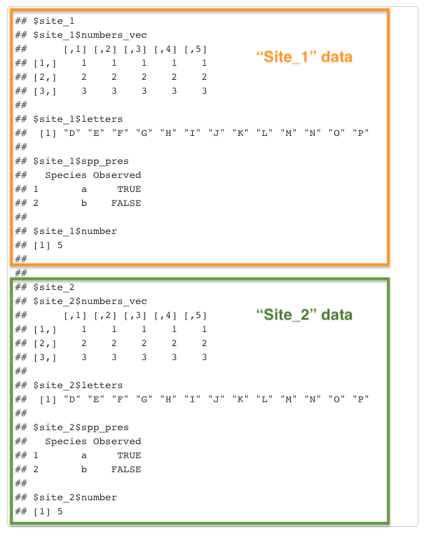

R also tells you how to access each of these data objects. e.g. to access the letters from site 1 you can do:

```r
##letters in site 1
our_second_list$site_1$letters
```

```
##  [1] "D" "E" "F" "G" "H" "I" "J" "K" "L" "M" "N" "O" "P"
```

You don’t need to name the different objects when you are making a `list()` (i.e. you dont have to do: `list("site_1" = our_list, site_2 = our_list)`, you can just do `list(our_list, our_list)`) but it often helps to have them well labelled so you dont get lost, especially when the lists get very complex!

Ok so thats enough of the different sorts of data you will encounter in R - you have a good understanding of these now and you will learn more by using them rather than just reading about them.

# 3 Functions outside of `base` R

**Time - 20 minutes**

Whilst `base` R includes a lot of very useful functions, it isnt exhaustive and we may (will) want to use functions which are not included in the basic installation. These are contained in “packages” which can be downloaded and installed onto your version of R. There are two main ways to install packages.

## 3.1 Packages on CRAN

The main (and easiest way) is through CRAN. CRAN is the [Comprehensive R Archive Network](https://cran.r-project.org/) and is where you downloaded R from at the beginning of this course. You can download packages in a number of different ways through CRAN. The easiest is to click on `Tools` -> `Install packages` at the top of your screen. The you can search for the package you want to install by name. The other option is to use the `install.packages()` function. Try this now:

```r
##use the install packages function to install the package "devtools" which we will use in a moment. dependencies = TRUE tells R to install any other packages that devtools relies on which you haven't already installed (I would always suggest keeping dependencies = TRUE when you are installing packages)
install.packages("devtools", dependencies = TRUE)
```

This will then install `devtools` and any packages `devtools` relies on to run. You might be asked something like the following

```
Do you want to attempt to install these from sources? (Yes/no/cancel)
```

If you do see this text then type `y` into your consol and press return. You should see R working busily to install the packages (lots of red text).

R is a fickle beast, and sometimes throw error messages up, e.g.:

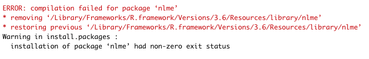

This can often be an issue with the installation process through RStudio, and the easiest fix is usually to open the R GUI and install through that instead:

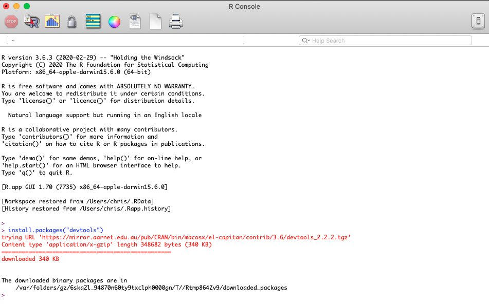

R and RStudio both share the same package directory, so any package installed through R is also available through RStudio.

Once this has finished you have installed the package. Congratulations! but you can’t yet use the package. Because there are so many packages for R (>15,514 on CRAN alone when I [checked](https://cran.r-project.org/web/packages/) in June 2020) we don’t want to have all of them running in R at the same time, so R differentiates between installing a package (via `install.packages()`) and loading a packing into the global environment. To load a package (once it is installed) use the `library()` function:

```r
##load the devtools package
library("devtools")
```

`devtools` is now installed and loaded into the global environment and you can use the functions in that library just like you have previously used the functions built directly into R (the `base` functions).

**Note** - you can see what packages are loaded into the global environment by clicking on the “Global Environment” drop down menu on the top right hand side of RStudio.

## 3.2 Packages on Github

The other major repository of R packages is on Github (which you are now familair with thanks to last week’s workshop). There are a number of reasons you might want to load packages from Github - the major one is that not all R packages are on CRAN, and the ones that aren’t on CRAN are typically on Github. CRAN is a bit of a pain when it comes to updating packages (its a long winded process) so you will often see minor changes, improvements, and bug fixes done on Github (every couple of days for the most popular packages), and then a major release on CRAN every few months. This can sometimes mean than Github versions are a little more unstable (think of them as beta versions of the packages), but generally they work fine.

We will use the following code to install a package (vroom) from Github. You will also need to install `Xtools` if you are working on a Mac (`Xtools` can be found for free in the `App store`).

To load packages from Github we need to install and load the devtools package (which we have already done). Then we can use the following code to load package:

```r
##install the "vroom" package
##The arguement for install_github takes the username and repository name where the package resides
##if we look at the vroom url: https://github.com/r-lib/vroom
##you can see that we just use the bit after github.com/:
install_github("r-lib/vroom")
```

You might need to click “Yes” to a pop-up asking if you want to install additional build tools when you run the above script.

*Note* - you many run into issues when attempting the above install, this is often because the type of package you are installing via CRAN (a **binary** package) is different from the type you are installing from Github (a **Source** package). This means you might see an error something similar to:

```
Downloading GitHub repo r-lib/vroom@master
Error: Failed to install 'vroom' from GitHub:
  System command 'R' failed, exit status: 1, stdout + stderr:
...
...
...
...
```

Once these packages are installed onto R then they act in exactly the same way, but **source** packages which feature C/C++ code require extra tools to install ([see](https://rstats.wtf/set-up-an-r-dev-environment.html#windows-system-prep) for tips to solve these issues).

*Windows* - Install Rtools from http://cran.r-project.org/bin/windows/Rtools/. During installation you will be asked to “Select Additional Tasks”. **DO NOT** select the box for “Add rtools to system PATH”. **DO** select the box for “Save version information to registry”.

*Mac OS* - Download Xcode from the App store (free) and install it.

Then try again to run `install_github("r-lib/vroom")`. Hopefully that will work. If you are having some issues then install `vroom` from CRAN for the moment (in the same way we installed `dev.tools`, and you can try it through the R GUI not RStudio) and you can try the Github install later.

A final option is to remove all the custom installed packages ( [see](https://www.r-bloggers.com/how-to-remove-all-user-installed-packages-in-r/) ) and then trying to reinstall.

## 3.3 Specifying functions from a specific package

A good rule of thumb is to only load the packages you NEED when running a script (e.g. don’t copy and paste a list of your most commonly used packages into each new script you make, unless you are actually going to use them all!). This is because there are so many R package that, unavoidably, there are functions with exactly the same name in multiple packages. This can obviously cause problems as the functions are likely to do slightly (or very!) different things - require different data, make different assumptions, and return different results. This could be catastrophic for your analysis and publications - and you don’t want to be retracting publications after they are out.

If there are multiple functions with the same name, then R will use the function from the last package you LOADED into the global environment (because this works exactly like overwriting objects and is called “masking” a function). If this isn’t the version you want to use, or you want to ensure you are using the correct version of a function, you can tell R to use a function from a specific package using the `::` operature:

```r
## tell R to use the "vroom()" function from the vroom package (see below)
vroom::vroom()
```

This says to R “look in the `vroom` package for the function `vroom()`”.

# 4 Loading data into R

**Time - 20 minutes**

So far we have considered data we have created in R (either entering values manually, or creating values with functions like `rnorm()`). However most of the time we will want to load data into R and manipulate/visualise/analyse these data.

There are a whole host of ways to load data into R (see [here](https://github.com/rstudio/cheatsheets/raw/master/data-import.pdf) for a bunch of different ways of doing it). The method you use might change depending on what sort of file the data you are trying to load are (e.g. are the a `.csv`, a `.txt`, a `.tsv` etc). We are going to concentrate on the two most common data sorts we will deal with in R: `.csv` files and `.RData` files.

## 4.1 `.csv` files

We use `.csv` files widely in R because they are a universal file format, and one which doesn’t allow any column formatting (i.e. if you open a `.csv` with excel you can’t colour the columns or change their widths and save those changes into the `.csv` file - decreasing the chances that those changes will interfere with the file being read into R). `.csv` files are restricted to matrix style data (i.e. data in 2 dimensions, matrices and data.frames), and so cannot store data in arrays or lists (but this isnt a big problem most of the time, as our data are often stored in data.frame style objects - see below for alternatives).

There are a range of functions which can be used to read in `.csv` files but we are going to use one from the `vroom` [package](https://github.com/r-lib/vroom) called `vroom`.

`vroom`is a powerful tool for dealing with really really big data sets (see benchmarking [here](https://vroom.r-lib.org/articles/benchmarks.html)). It does this by not reading all of your data (counterintuitively) but by indexing where records are kept so they can be read when needed (see [here](https://github.com/r-lib/vroom) for futher details). It’s simple to use so we will just use it as our go-to function for reading in data, and also supports a range of data types (including zip, gz, bz2 and xz compressed files automatically) so is a good package to get to grips with. We will look at two examples of how to use this - one for loading files from your local computer, and one for loading files directly from Github.

### 4.1.1 Loading from your local computer

The most basic use of `vroom()` is to load a `.csv` file from your computer hardrive into R. To try this out download the `.csv` file from this [link](https://raw.githubusercontent.com/chrit88/Bioinformatics_data/master/Workshop%203/wader_data.csv) by right-clicking on the white space next to the data, then selecting “save as”, and then saveing it into your working folder.

#### 4.1.1.1 Manual pathways

Now we have a data set to load in we can go ahead and load it. The most basic way to do this is to specify the filepath of where the file is. You can find the patway to your file by right clicking on it in your brower and selecting “Get info” (Mac OS) or “Properties” (Windows). You can then simply tell R where this file is. In my case:

```r
##make sure vroom is loaded into your R session (you only need to do this once)
library(vroom)

##read in the wader data set
wad_dat <- vroom("~/Desktop/Work/Wading bird analysis/Data/wader_data.csv")
```

```
## Rows: 33
## Columns: 4
## dbl [4]: Year, BreedingPairs, AvgMass, SDMass
##
## Pass a specification to the `col_types` argument to quiet this message
```

*NOTE* if you are using MacOS then the file path will be with “`/`”, if you are using windows then they will need to be “`\`”

Do this for your own data now.

You can check this has worked by looking at the object using the `head()` function which displays (by default) the top 6 rows of an object:

```r
##look at the top of the data
head(wad_dat)
```

```
## # A tibble: 6 x 4
##    Year BreedingPairs AvgMass SDMass
##   <dbl>         <dbl>   <dbl>  <dbl>
## 1  1984           391    541.   34.7
## 2  1985           420    536.   36.5
## 3  1986           429    529.   37.8
## 4  1987           418    542.   38.5
## 5  1988           423    531.   31.9
## 6  1989           406    524.   40.2
```

#### 4.1.1.2 Relative pathways

A more powerful approach - particularly if you are working in a github repository (**which you should be doing for this course!**) - is to make R look for a file in a place which is relative to the location of the R script you are working in. Look at how I have my Github repository organised:

[figure not shown]

I have a folder (“Wading bird analysis”) inside which I have two subfolders - one containing the wading bird data (`wader_data.csv`), the other containing the R script I am working on for this analsis. We can tell R to look for this `wader_data.csv` file using the following code:

```r
##first we set the working directory (which is the location of the current file you are working on):
setwd(dirname(rstudioapi::getActiveDocumentContext()$path))

##then read in the data using vroom:
wad_dat <- vroom('./Data/wader_data.csv')
```

The trick here is that where as in the original absolute pathway we specificied exactly where on the computer the file was, in the relative pathway we tell RStudio to look in a location specified from where the R script is. This is done using the `./` argument at the beginning of the file pathway - a single `.` before the first `/` tells R studio to move one folder higher in the chain (i.e. from *R code* to *Wading bird analysis*) in this example:

[figure not shown]

And then look for a folder called *Data*, and then look inside that folder for a file called *wader_data.csv*. We can specify the number of levels higher that R should start searching for the beginning of the file path using more `.`:

```r
##Look two folders up the chain.
vroom('../Data/wader_data.csv')
```

Relatively pathways are particularly useful when you are working in a Github repository. Remember, you store your data and your code in a github repository, so that when someone clones your repository they will recieve the code and data (in exactly the same folders you have) so the relatively pathways (and thus the code) will run for them without them having to specify a new absolute location on their local computer. This is best practice for making your code sharable and your science open.

*Task*

Navigate to the [Bioinformatics Data github repository](https://github.com/chrit88/Bioinformatics_data) and download the Covid data set. Put this in a sensible file in your github repository, and then load this data into R using the relative pathway technique detailed above.

### 4.1.2 Loading from Github

You can also load files in directly from Github (or other online data repository). This can be useful if those data are being regularly updated (and you dont want to keep downloading them onto your computer) or if the file is too big to be stored on Github (which has a 1gb repository limit) but you want the data to be readily accessible along with the code. Doing this is actually really easy. You need to navigate to the data file you want to load from Github, click on that file and you should see this screen:

[figure not shown]

Then click on *Raw*, and copy the URL into `vroom()` as below:

```r
##use vroom to read in some data from github:
covid_dat <- vroom("https://raw.githubusercontent.com/chrit88/Bioinformatics_data/master/Workshop%203/time_series_covid19_deaths_global.csv")
```

```
## Rows: 266
## Columns: 180
## chr [  2]: Province/State, Country/Region
## dbl [178]: Lat, Long, 1/22/20, 1/23/20, 1/24/20, 1/25/20, 1/26/20, 1/27/20, 1/28/20, 1/29/20...
##
## Pass a specification to the `col_types` argument to quiet this message
```

Running this will download the data and load it into RStudio. (We will look at this covid-19 data later.)

*Note* - this requires an internet connection, so isn’t a good option if you need to work offline!

#### 4.1.2.1 Loading multiple files

`vroom` can also load multiple files simultaneously, combining them into a single object (as long as the column names are the same across the different files). `vroom` provides a nice example of this in their vignette:

```r
##you can ignore this code for the moment if you want
##but to briefly summarise it is reading in some data included in base R
##and then splitting it into 3 differnt data.frame style objects based on the values in one of the columns ("cyl")
mt <- tibble::rownames_to_column(mtcars, "model")
purrr::iwalk(
  split(mt, mt$cyl),
  ##save this split files in to the default directory
  ~ vroom_write(.x, glue::glue("mtcars_{.y}.csv"), "\t")
)
```

You should be able just to run that on your computer as it is. The interesting bit is how `vroom()` handles the read in of these three files:

```r
##find files in the default directory which start with "mtcars" and end in "csv"
##save these file names as an object called "files"
files <- fs::dir_ls(glob = "mtcars*csv")

##these are then the names of the files matching the above arguments:
files
```

```
## mtcars_4.csv mtcars_6.csv mtcars_8.csv
```

```r
##then load these file names using vroom
vroom(files)
```

```
## Rows: 32
## Columns: 12
## chr [ 1]: model
## dbl [11]: mpg, cyl, disp, hp, drat, wt, qsec, vs, am, gear, carb
##
## Pass a specification to the `col_types` argument to quiet this message
```

```
## # A tibble: 32 x 12
##    model         mpg   cyl  disp    hp  drat    wt  qsec    vs    am  gear  carb
##    <chr>       <dbl> <dbl> <dbl> <dbl> <dbl> <dbl> <dbl> <dbl> <dbl> <dbl> <dbl>
##  1 Datsun 710   22.8     4 108      93  3.85  2.32  18.6     1     1     4     1
##  2 Merc 240D    24.4     4 147.     62  3.69  3.19  20       1     0     4     2
##  3 Merc 230     22.8     4 141.     95  3.92  3.15  22.9     1     0     4     2
##  4 Fiat 128     32.4     4  78.7    66  4.08  2.2   19.5     1     1     4     1
##  5 Honda Civic  30.4     4  75.7    52  4.93  1.62  18.5     1     1     4     2
##  6 Toyota Cor…  33.9     4  71.1    65  4.22  1.84  19.9     1     1     4     1
##  7 Toyota Cor…  21.5     4 120.     97  3.7   2.46  20.0     1     0     3     1
##  8 Fiat X1-9    27.3     4  79      66  4.08  1.94  18.9     1     1     4     1
##  9 Porsche 91…  26       4 120.     91  4.43  2.14  16.7     0     1     5     2
## 10 Lotus Euro…  30.4     4  95.1   113  3.77  1.51  16.9     1     1     5     2
## # … with 22 more rows
```

You can see that `vroom()` now returns a single file which is the combination of the three files we read in. Don’t worry about trying to understand all the detail provided - thats what we will be doing in the next section.

## 4.2 .RData

One other very useful file type to know about in R is `.RData`, which is (unsurprisingly) specific to the R progrmaming language. This has its advantages (its very space efficient, and you arent restricted to dealing with 2 dimensional tables as you are with the `.csv` file type - i.e. you can share complex data types like lists, matrices, etc) but the draw back is that you can’t open it in other programmes (e.g. like a `.csv` file where you can open it in Excel and visualise it).

`.RData` are loaded into R using the `load()` function in much the same way as `.csv` files are:

```r
##load in some RData
load("my_data/pathway/my_data.RData")
```

However, you don’t need to specify an object to save the data too as it will just directly load the object my_data into the R environment, so you can access it as you would any other data of that type (be it a vector, matrix, array, data.frame etc).

# 5 Writing data out of R

**Time - 5 minutes**

Of course the other important part of data use in R is being able to save the data out again - this can be useful if you need to share the output of a simulation, or manipulate data and pass it onto a collaborator, or share the data when you publish a paper.

## 5.1 .csv

To export a `.csv` file we can again use the `vroom`:

```r
##write out a .csv file
vroom_write(my_data, "a pathway/a data folder/the_name_of_my_data.csv")
```

Where `my_data` is a data.frame, the second argument is the path you want to write the data too and the name you want to save it as.

`vroom_write` can also export a bunch of other smart data formats for large data sets (and allows compression of data for easy sharing if the files are large, see [here](https://cran.r-project.org/web/packages/vroom/vignettes/vroom.html)).

## 5.2 RData

Similarly, RData can be written out using the `save()` function in `base`:

```r
##write out my data as an RData file:
save(my_data, file = "a pathway/a data folder/the_name_of_my_RData.RData")
```

However we can here specify as many items as we want to save out, and these data types can be anything R can handle (vector, list, array, etc):

```r
##write out my data as an RData file:
save(my_data,
     my_vector,
     my_list,
     my_array,
     file = "a pathway/a data folder/the_name_of_my_RData.RData")
```

the above would this save all of those data objects as a single `.RData` file, and when you load that `.RData` file in all of those objects would be available straight away in the global environment under their original names. Nifty!

# 6 Data handling

**Time - 20 minutes**

So now you can read in data to R and you know the basic functunalities of R - now its time to start the data manipulation/visualisation/analysis pipeline. We are going to approach this as follows:

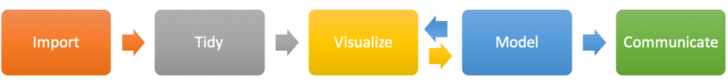

So far we have covered the *Import* part of this workflow (during this session) and you have done some work on the *Communicate* section when you worked with RMarkdown and Github. Today we will start to fill in the missing middle sections, starting with data tidying.

## 6.1 Package options

### 6.1.1 The `tidyverse`

For the majority of the work in the “tidy” and “visualise” sections of the data handling process we are going to use a suite of packages called the [`tidyverse`](https://www.tidyverse.org/). The tidyverse is a collection of some of the most useful packages in R, and the nice thing about these packages is that they share some underlying goals - the same design philosophy, grammar, and data structures. This means that you have less syntax to learn and you should be able to progress much faster with your R coding.

[figure not shown]

You can install all of the packages in the `tidyverse` at once, using:

```r
##install the tidyverse
install.packages("tidyverse")
```

and then loading as normal:

```r
##load the tidyverse
library("tidyverse")
```

You will see that this installation has loaded a number [packages](https://www.tidyverse.org/packages/) in your global environment:

```
── Attaching packages ─────────────── tidyverse 1.3.0 ──
✓ ggplot2 3.3.0     ✓ purrr   0.3.3
✓ tibble  3.0.0     ✓ dplyr   0.8.5
✓ tidyr   1.0.2     ✓ stringr 1.4.0
✓ readr   1.3.1     ✓ forcats 0.5.0
── Conflicts ──────────────────────── tidyverse_conflicts() ──
x dplyr::filter() masks stats::filter()
x dplyr::lag()    masks stats::lag()
```

and helpfully it has flagged any functions which tidyverse has “masked” from other packages (see Specifying functions from a specific package). We will use a number of these packages over the next few weeks (but you won’t neccesarily know they are from different packages as we have just loaded the entire `tidyverse` and can use functions from any of its packages - remember if you want more information you can use the `?`). There is also an excellent free online book on the [`tidyverse`](https://r4ds.had.co.nz/).

### 6.1.2 Pipelines

The `tidyverse` differs from most other R packages in that it makes use of pipelines. A pipeline is just a way of chaining a series of functions together, and means that you don’t have to save objects out of a function and then push those objects into another function - the data created using one function are passed straight to the next function in the chain.

It’s best to learn this through doing, but to give you a broad idea of how we build these chains in R they take the form of: (1) the data you want to apply the function/s to, (2) the function/s you want to apply, separated by a new operator `%>%`:

```
my_data %>% function_1() %>% function_2()
```

This reads as “take `my_data`, apply `function_1()` to that data, then apply `function_2()` to that data produced when I apply `function_1()`”. More on that later.

Whilst the tidyverse is a very useful suite of functions it is worth pointing out that with very large data sets (>>1GB of data) it can start to slow down considerable. If your data are larger than this there are other options, the best of which is `data.table`.

### 6.1.3 `data.table`

The `data.table` package has been specifically designed to deal with “big” data - happily dealing with files over 10GB in size and not chewing up your RAM. Its function’s are optimised for these big data sets (see [benchmarking](https://h2oai.github.io/db-benchmark/)), but often aren’t the most intuitive or easy to read code. We are going to focus on `tidyverse` to give you a single set of syntax to be familiar with, but `data.table` might be an excellent option for your future work (see [here](https://atrebas.github.io/post/2019-03-03-datatable-dplyr/) for `data.table` syntax compared to `tidyverse`).

[figure not shown]

## 6.2 Summarising data

So far we have loaded in two data files to R - I’ve called them `wad_dat` and `covid_dat`. We will use these to go through some basic (and increasingly more complex) data manipulation stratergies.

First off, lets look at the `covid_dat` data set. First, lets check what type of object *covid_dat* is:

```r
##what class is the object
class(covid_dat)
```

```
## [1] "spec_tbl_df" "tbl_df"      "tbl"         "data.frame"
```

You can see that covid_data has **four** classes: `spec_tbl_df`, `tbl_df`, `tbl` and `data.frame`. Data.frames we encountered earlier - these are obejcts which can mix differnt sorts of data. So what is a `spec_tbl_df`, `tbl`, and `tbl_df`? The `tbl` in these stands for `tibble` - which is a kind of `data.frame`. `tibble` are the universal data type which the `tidyverse` uses (remember that underlying set of goals we mentioned earlier). `covid_dat` is a tibble because we read it in using `vroom` - whose output is a `tibble` (`vroom` was created by the same people who are developing the `tidyverse` and will be probably be moved into the tidyverse `shortly`).

`tibbles` have the nice property of, when you run them in the console, having a good deal of information on them automatically displayed:

```r
##look at the data
covid_dat
```

[output not shown]

There are bunches of useful information in this output. You can see:

So from this output we can conclued that these data are a bit of a mess - we have variables (Provice/State, Country/Region, Lat, Long) in the left four columns, followed by a series of columns, each with a date as a heading. These are the **cumulative** reported numbers of deaths per Provice/State and/or Country/Region over time due to Covid-19. Data are often input into an Excel spread sheet in this way, as we have a fixed set of variables (Provice/State, Country/Region, Lat, Long) whilst the information on deaths was being updated every few days. Therefore it is easy to just add another column onto the right-hand side of the Excel table and add in the new data. We call this a *wide* data format.

Moreover, we have another potential problem in our column titles: there is an operator (the divide symbol `/`) in the names of the first two columns “Province/State” & “Country/Region”. Its also present in the column headings which are dates, but it isnt such a problem here as we are going to be reshaping the data in a minute. To avoid R trying to divide an object called `Province` by an object called `State` and failing to find either at some point in the future, we will just replace the `/` in these names with something else:

```r
##change the first two names of our data frame
names(covid_dat)[1:2] <- c("Province.State", "Country.Region")
```

So our data is in wide format - unfortunately computers (for the most part) hate this sort of data. This means we need to reshape it.

## 6.3 Basic data reshaping with `pivot_`

So we need to change this data to long format. The `tidyverse` provides functions for reshaping data from *wide to long* and from *long to wide* which are helpfully the inverse of one another. These are the `pivot_` functions.

[figure not shown]

To shape data from wide to long format, we use the `pivot_longer()` function. We going to use this with the new operator we mentioned earlier: `%>%` - [the `magrittr` operator](https://magrittr.tidyverse.org/).

```r
##so this says take our data frame called covid_dat
covid_long <- covid_dat %>%
                ##and then apply this function
                pivot_longer(cols = -c( Province.State,
                                        Country.Region,
                                        Lat,
                                        Long))
```

As you can see, we use `cols =` to specify the columns we want pivot_longer to use to pivot the data around.

*Note* the hard to spot `-` before the vector of columns! Also, that unlike a lot of other R functions we dont need to use the `""` to specify that we are talking about a name not an object - tidyverse aims to do away with unneccesary coding like that, and assumes arguments given inside functions are related to object WITHIN the data - i.e. in the local environment of that function, not in the global environment, and so will try to match them in the data first, but will then look in the global environment for those objects if it cant find them in the data we have provided the function. This is why earlier we removed the `/` operator from the names as this interferes with the workings.

*Task*

Try running the code above on the Covid data you have loaded into your R session, and then look at the new `data.frame` produced. How is it different from the previous (wide) data frame? Do you have appropriate names for the different columns?

So, `pivot_longer()` has then assumed that all the other columns we havent specified are the values/observations we want to put into the long format, and that the names of those columns (the dates the observations were made at) will form a new column called “name”. We can specify the names of these two new columns using names_to and values_to. Its also worth pointing out that we don’t have to type all of the column names out (which can be really annoying if we have lots and lots of variable columns we want to keep), but can specify that pivot_longer() should use the columns from one name to another (e.g. `Province.State:Long` would mean use all the columns from `Province.State` to `Long`).

```r
##our data frame
covid_long <- covid_dat %>%
                ##and then apply this function
                pivot_longer(cols = -c(Province.State:Long),
                             names_to = "Date",
                             values_to = "Deaths")
```

We’ve established that most analyses and plotting techniques for data use long not wide format data. However, this isn’t always the case and there are some instances where we want to make our data wide from its current long format. This is done via `pivot_wider()` (i.e. the opposite of `pivot_longer()`). For `pivot_wider()` we specify two columns - one which contain the names of the soon to be made columns (remember the structure of the original `covid_dat` where the dates were the column names), and one which contains the values/observations that will go into those columns:

```r
##change long to wide
covid_long %>%
  pivot_wider(names_from = Date,
              values_from = Deaths)
```

# 7 Key Concepts

Ok, we will leave it there for today. Let’s remember the key take home points from todays workshop:

- Matrices - 2 dimensions containing a single type of data
- Arrays are n dimensional matrices containing a single type of data
- `data.frames` (including `tibble`) can contain multiple data types
- Lists - structures containing nested information of multiple types
- Installing packages from CRAN via `install.packages(“package.name”)
- Installing packages from Github via `install_github("r-lib/vroom")`
- We can specify a function to be used from a certain package using the `::` operator: `vroom::vroom()`
- Load data into R using `vroom()` via direct pathways, or using a relative pathway
- Load data from Github using `vroom()` and the data url
- Creating pipelines via the magrittr operator %>%
- Reshaping data from wide to long and long to wide using the `pivot_` functions

# 8 Functions covered today

| Function/operator | Call |
| --- | --- |
| Create a matrix | `matrix()` |
| Sequence of regular numbers | `seq()` |
| Dimensions of an object | `dim()` |
| Matrix multiplication | `%*%` |
| Transpose | `t()` |
| Create matrix where diagonal is filled with x | `diag()` |
| Return the diagonal of a matrix | `diag()` |
| Calculate eighenvalues and eigenvectors | `eigen()` |
| Sums of the rows | `rowSums()` |
| Sums of the columns | `cowSums()` |
| Means of the rows | `rowMeans()` |
| Means of the columns | `colMeans()` |
| Make an array | `array()` |
| Make a data.frame | `data.frame()` |
| Make a list | `list()` |
| Install a package from CRAN | `install.packages()` |
| Install a package from Github | `install_github()` |
| Load a package into the global environment | `library()` |
| Reading in data | `vroom()` |
| Set working directory to file location | `setwd(dirname(rstudioapi::getActiveDocumentContext()$path))` |
| Check the class of an object | `class()` |
| Change a file from wide to long format | `pivot_longer()` |
| Change a file from long to wide format | `pivot_wider()` |

# 9 Cheat sheets

[Data import and reshaping cheatsheet](https://github.com/rstudio/cheatsheets/raw/master/data-import.pdf)

[`tidyverse`](https://r4ds.had.co.nz/)

# 10 Homework

## 10.1 Homework solution for last week

Your homework last week was to:

- Go through and ensure you have understood everything from today’s practical.
- Use RMarkdown to summarise the most important bits of what you have learned so far - i.e. make a sort of cheat sheet for yourself of useful functions or insights. This will be different for everyone, so I won’t tell you what to put on it but I do suggest you include a table of useful functions which you have come across during your reading.
- Download the data for the rest of this course onto your computer and add it to your repository: https://github.com/chrit88/Bioinformatics_data)
- Create a comprehensive `README.md` file, describing what is in the repository, what the repository is for, links to relevant data sources etc
- Publish your repository and make it public, and then send a link to your repository to us so we can give you feedback on the structure, README, etc

Given these tasks we can’t easily share you a “good example”, but you will get feedback on the repository you sent us.

## 10.2 This week’s homework

You are going to practice some of the skills you learned today, and also reinforce some of the skills you learned over the last two weeks.

1. As with last week, the first thing to do is to ensure you have gone through - and understood - the information above in full.
2. Write an Rmarkdown describing (and including code to do) the following:
   - load `to_sort_pop_1.csv` and `to_sort_pop_1.csv` from [bioinformatics_data](https://github.com/chrit88/Bioinformatics_data/tree/master/Workshop%203) on github.
   - these data are population counts for endangered species. The first four columns should be self explanitory (the species binomial, and the primary, secondary, and tertiary threat each species is being threatened by). The rest of the columns specify the population counts for given dates. If you compare the two data (`to_sort_pop_1.csv` vs `to_sort_pop_1.csv`) you will see that the population is specified in the names of the date columns.
   - using `tidyverse` `join` both of these data together into a single tibble
     - you haven’t met the `join` function yet, but 90% of being a good coder (and hence bioinformatician) is being good at googling and learning how to learn code!
   - reshape them from wide to long format
   - make sure when you do this that you end up with (1) a column specifying which population the data are from (i.e. population 1 or 2), (2) a column specifying the date the data were collected, (3) a column with the population abundance estimates in it, and (4) that any missing values are dropped from the data. I.e. your data.frame should look like the figure below.
   - do the above with the **minimum** amount of code (hint - `%>%`!)
   - In your RMarkdown make sure you explain what you have done and show your annotated code.

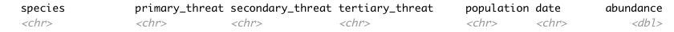